# Homework 8: Group 1

#### SVM (Logan Housing Data)

David Jung, Ryan Voges, Emily Blake, Spencer Powell, Abraham Alhomadi

```python
import numpy as np
import pandas as pd
import matplotlib.pyplot as plt
import seaborn as sns
from sklearn.linear_model import LinearRegression
import statsmodels.api as sm
import scipy.stats as ss
sns.set()
import warnings
warnings.filterwarnings('ignore')
```

```python
rand_state = 1000
```

#### Question 1 EDA (30 points)

In this exercise I want you to do a quick EDA on the Logan housing data set. The data are 4110 observations of Logan housing prices from 2018 to 2020. All the variable names are self explanatory except the DOM which stands for Days On the Market. The data was originally provided to the course by Jeffrey! Jeff is working on this exciting dataset for his master’s thesis. Please do not share this data set with anyone outside of the class.

Show me what you have learned from the previous EDAs you did in HW2 and HW3. Try to come up with an interesting story (hypothesis) using this data set. For example, that would be interesting to see the breakdowns of Logan house prices by year, location etc. Treat this exercise as a real world project. Many times the managers have no idea what they want from the data!! your job is to be as creative as possible and come up with informative charts and tables.

```python
df = pd.read_csv("Logan_housing.csv")
```

```python
df.info()
```

```
<class 'pandas.core.frame.DataFrame'>
RangeIndex: 4110 entries, 0 to 4109
Data columns (total 16 columns):
 #   Column             Non-Null Count  Dtype
---  ------             --------------  -----
 0   Sold Price         4110 non-null   int64
 1   DOM                4110 non-null   int64
 2   Garage Capacity    4110 non-null   int64
 3   HOA Fee            4110 non-null   int64
 4   Irregular Shape    4110 non-null   object
 5   Quadrant           4110 non-null   object
 6   School District    4110 non-null   object
 7   Sold Terms         4110 non-null   object
 8   Total Bedrooms     4110 non-null   int64
 9   Total Bathrooms    4110 non-null   int64
 10  Total Square Feet  4110 non-null   int64
 11  Year Built         4110 non-null   int64
 12  Zip                4110 non-null   int64
 13  year_sold          4110 non-null   int64
 14  month_sold         4110 non-null   int64
 15  built_after_2000   4110 non-null   int64
dtypes: int64(12), object(4)
memory usage: 513.9+ KB
```

```python
df.isna().sum()
```

```
Sold Price           0
DOM                  0
Garage Capacity      0
HOA Fee              0
Irregular Shape      0
Quadrant             0
School District      0
Sold Terms           0
Total Bedrooms       0
Total Bathrooms      0
Total Square Feet    0
Year Built           0
Zip                  0
year_sold            0
month_sold           0
built_after_2000     0
dtype: int64
```

```python
df.head()
```

|  | Sold Price | DOM | Garage Capacity | HOA Fee | Irregular Shape | Quadrant | School District | Sold Terms | Total Bedrooms | Total Bathrooms | Total Square Feet | Year Built | Zip | year_sold | month_sold | built_after_2000 |
| --- | --- | --- | --- | --- | --- | --- | --- | --- | --- | --- | --- | --- | --- | --- | --- | --- |
| 0 | 176000 | 5 | 2 | 0 | No | NW | Cache | FHA | 3 | 1 | 1031 | 1974 | 84335 | 2018 | 9 | 0 |
| 1 | 225000 | 6 | 2 | 0 | No | NW | Cache | Conventional | 4 | 2 | 2091 | 1995 | 84335 | 2018 | 7 | 0 |
| 2 | 274900 | 14 | 2 | 0 | No | NW | Cache | Conventional | 3 | 1 | 2016 | 1980 | 84335 | 2018 | 11 | 0 |
| 3 | 175000 | 16 | 1 | 0 | No | NW | Cache | USDA Rural Development | 4 | 1 | 1920 | 1978 | 84335 | 2018 | 6 | 0 |
| 4 | 179000 | 29 | 0 | 0 | No | NW | Cache | Cash | 4 | 2 | 1329 | 1976 | 84335 | 2018 | 9 | 0 |

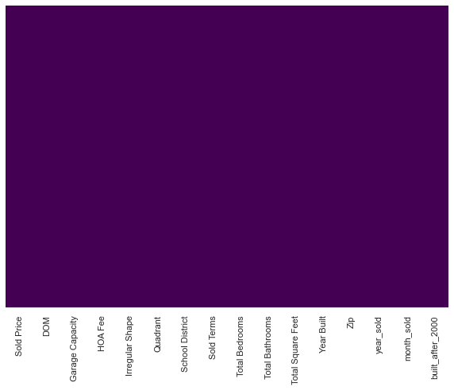

```python
# Now look at "nan" values:
plt.figure(figsize=(10,7))
sns.heatmap(df.isnull(),yticklabels=False,cbar=False,cmap='viridis')
plt.show()
```

```python
# Look if duplicates in our dataset:
sum(df.duplicated())

# There are two rows that are duplicates.
```

```
2
```

```python
# We have some duplicates, so let's drop them!
df.drop_duplicates(inplace=True)
```

```python
sum(df.duplicated())
```

```
0
```

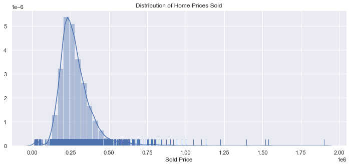

```python
# Lets check out some distributions:
plt.figure(figsize=(12,5))
sns.distplot(df["Sold Price"], 50, kde=True, rug=True)
plt.title('Distribution of Home Prices Sold')
plt.show()
```

#### We could see that our data is heavily right skewed.

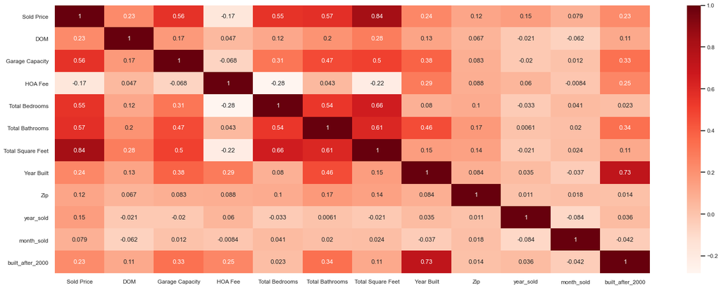

```python
# Examining possible correlation between sold price and other variables:

sns.set(rc={'figure.figsize':(27,10)})
sns.set_context("talk", font_scale=0.7)

sns.heatmap(df.iloc[:,:].corr(), cmap='Reds', annot=True)
```

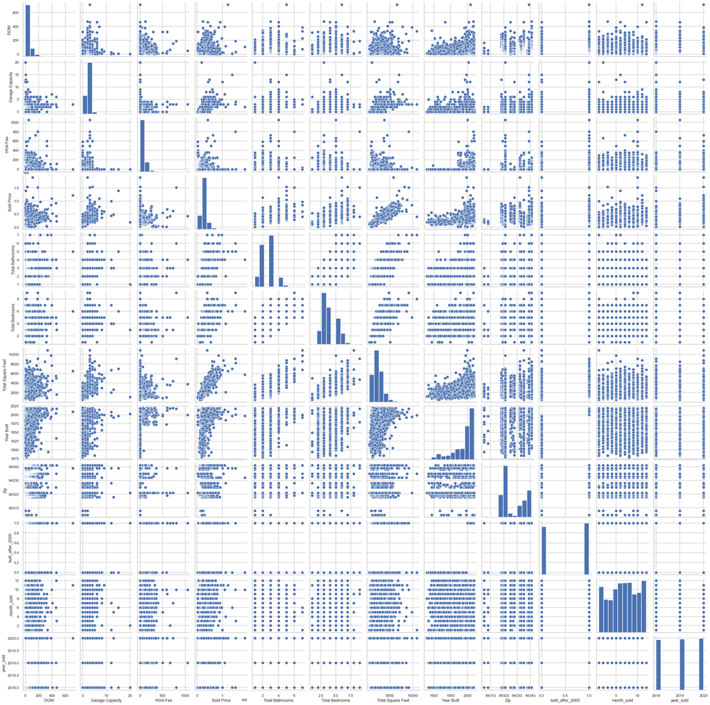

```python
sns.set_style('whitegrid')
sns.pairplot(df[df.columns.difference(df)])
```

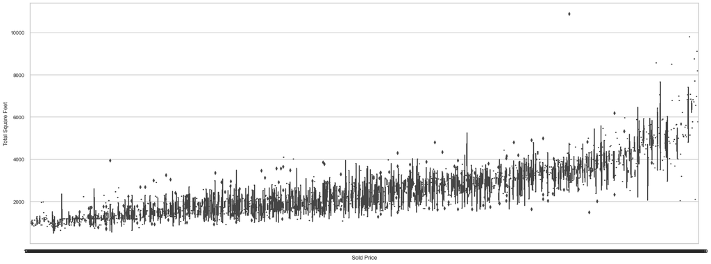

```python
# Now will look at relationship between Sold Price and Total Square Feet:

sns.boxplot(x='Sold Price', y='Total Square Feet',data=df)
```

```python
# Looking at the unique variables
for col in df.columns:
    print(col, df[col].nunique())
```

```
Sold Price 1217
DOM 248
Garage Capacity 14
HOA Fee 96
Irregular Shape 2
Quadrant 4
School District 2
Sold Terms 6
Total Bedrooms 9
Total Bathrooms 7
Total Square Feet 2009
Year Built 136
Zip 16
year_sold 3
month_sold 12
built_after_2000 2
```

```python
df.describe()
```

|  | Sold Price | DOM | Garage Capacity | HOA Fee | Total Bedrooms | Total Bathrooms | Total Square Feet | Year Built | Zip | year_sold | month_sold | built_after_2000 |
| --- | --- | --- | --- | --- | --- | --- | --- | --- | --- | --- | --- | --- |
| count | 4.108000e+03 | 4108.000000 | 4108.000000 | 4108.000000 | 4108.000000 | 4108.000000 | 4108.000000 | 4108.000000 | 4108.000000 | 4108.000000 | 4108.000000 | 4108.000000 |
| mean | 2.821410e+05 | 40.541383 | 1.825949 | 36.149708 | 3.821568 | 2.577167 | 2370.712756 | 1989.272395 | 84327.367089 | 2019.009981 | 6.678676 | 0.517283 |
| std | 1.178898e+05 | 51.578459 | 1.094350 | 69.567184 | 1.182846 | 0.851321 | 1049.821233 | 31.285221 | 8.616500 | 0.816585 | 3.032968 | 0.499762 |
| min | 1.300000e+04 | 1.000000 | 0.000000 | 0.000000 | 1.000000 | 1.000000 | 520.000000 | 1879.000000 | 84305.000000 | 2018.000000 | 1.000000 | 0.000000 |
| 25% | 2.140000e+05 | 6.000000 | 1.000000 | 0.000000 | 3.000000 | 2.000000 | 1583.000000 | 1976.000000 | 84321.000000 | 2018.000000 | 4.000000 | 0.000000 |
| 50% | 2.600000e+05 | 23.000000 | 2.000000 | 0.000000 | 4.000000 | 3.000000 | 2141.000000 | 2001.000000 | 84321.000000 | 2019.000000 | 7.000000 | 1.000000 |
| 75% | 3.249000e+05 | 56.000000 | 2.000000 | 65.000000 | 5.000000 | 3.000000 | 2942.250000 | 2012.000000 | 84335.000000 | 2020.000000 | 9.000000 | 1.000000 |
| max | 1.900000e+06 | 712.000000 | 20.000000 | 1050.000000 | 9.000000 | 7.000000 | 10890.000000 | 2020.000000 | 84341.000000 | 2020.000000 | 12.000000 | 1.000000 |

After examining the dataset, we have many features with observations that are considered outliers. For garage capacity, it is unlikely that more than a few houses will have up to 20 spots available. A house that spends 712 DOM is also very unlikely and well above the rest of the dataset. We decided to go ahead and remove them in order to get much more accurate predictions.

```python
categorical = ['Irregular Shape', 'Quadrant', 'School District', 'Sold Terms', 'Year Built', 'Zip', 'year_sold', 'month_sold', 'built_after_2000',]

for col in categorical:
    df[col] = df[col].astype("category")
```

```python
# Here we want to remove any outliers outside of 4 standard deviations from the mean in each feature
z_scores = ss.zscore(df.drop(categorical, axis = 1))
abs_z_scores = np.abs(z_scores)
filtered_entries = (abs_z_scores < 4).all(axis=1)
df = df[filtered_entries]
print(df)
```

```
      Sold Price  DOM  Garage Capacity  HOA Fee Irregular Shape Quadrant  \
0         176000    5                2        0              No       NW
1         225000    6                2        0              No       NW
2         274900   14                2        0              No       NW
3         175000   16                1        0              No       NW
4         179000   29                0        0              No       NW
...          ...  ...              ...      ...             ...      ...
4103      370000  215                2      150              No       NE
4106      272000    6                0        0             Yes       SW
4107      298000   40                0        0              No       SW
4108      215000   49                0        0              No       SW
4109      450000   94                3        0              No       SW

     School District              Sold Terms  Total Bedrooms  Total Bathrooms  \
0              Cache                     FHA               3                1
```

[output cut: 38 more lines]

```python
df.describe()
```

|  | Sold Price | DOM | Garage Capacity | HOA Fee | Total Bedrooms | Total Bathrooms | Total Square Feet |
| --- | --- | --- | --- | --- | --- | --- | --- |
| count | 3996.000000 | 3996.000000 | 3996.000000 | 3996.000000 | 3996.000000 | 3996.000000 | 3996.000000 |
| mean | 275080.770771 | 37.833083 | 1.784034 | 33.212713 | 3.796797 | 2.546296 | 2315.945946 |
| std | 93122.677252 | 43.525027 | 0.943010 | 58.056718 | 1.153001 | 0.803689 | 929.600439 |
| min | 20000.000000 | 1.000000 | 0.000000 | 0.000000 | 1.000000 | 1.000000 | 520.000000 |
| 25% | 213587.500000 | 6.000000 | 1.000000 | 0.000000 | 3.000000 | 2.000000 | 1582.500000 |
| 50% | 259000.000000 | 22.000000 | 2.000000 | 0.000000 | 4.000000 | 3.000000 | 2129.000000 |
| 75% | 320000.000000 | 54.000000 | 2.000000 | 65.000000 | 5.000000 | 3.000000 | 2896.250000 |
| max | 751750.000000 | 246.000000 | 6.000000 | 300.000000 | 8.000000 | 5.000000 | 6475.000000 |

#### Question 2 SVM Regression (60 points)

1. Define the categorical variables and transform them into dummy variables (if you haven’t done this already in Question 1). (5 points)

```python
df.head()
```

|  | Sold Price | DOM | Garage Capacity | HOA Fee | Irregular Shape | Quadrant | School District | Sold Terms | Total Bedrooms | Total Bathrooms | Total Square Feet | Year Built | Zip | year_sold | month_sold | built_after_2000 |
| --- | --- | --- | --- | --- | --- | --- | --- | --- | --- | --- | --- | --- | --- | --- | --- | --- |
| 0 | 176000 | 5 | 2 | 0 | No | NW | Cache | FHA | 3 | 1 | 1031 | 1974 | 84335 | 2018 | 9 | 0 |
| 1 | 225000 | 6 | 2 | 0 | No | NW | Cache | Conventional | 4 | 2 | 2091 | 1995 | 84335 | 2018 | 7 | 0 |
| 2 | 274900 | 14 | 2 | 0 | No | NW | Cache | Conventional | 3 | 1 | 2016 | 1980 | 84335 | 2018 | 11 | 0 |
| 3 | 175000 | 16 | 1 | 0 | No | NW | Cache | USDA Rural Development | 4 | 1 | 1920 | 1978 | 84335 | 2018 | 6 | 0 |
| 4 | 179000 | 29 | 0 | 0 | No | NW | Cache | Cash | 4 | 2 | 1329 | 1976 | 84335 | 2018 | 9 | 0 |

```python
# Since we have the variable "built_after_2000", we can drop "Year Built" to avoid too many dummy variables
df.drop("Year Built", axis = 1, inplace = True)
```

```python
df = pd.get_dummies(df, drop_first=True)
```

```python
df.columns
```

```
Index(['Sold Price', 'DOM', 'Garage Capacity', 'HOA Fee', 'Total Bedrooms',
       'Total Bathrooms', 'Total Square Feet', 'Irregular Shape_Yes',
       'Quadrant_NW', 'Quadrant_SE', 'Quadrant_SW', 'School District_Logan',
       'Sold Terms_Conventional', 'Sold Terms_FHA', 'Sold Terms_Other',
       'Sold Terms_USDA Rural Development', 'Sold Terms_VA', 'Zip_84308',
       'Zip_84318', 'Zip_84319', 'Zip_84320', 'Zip_84321', 'Zip_84325',
       'Zip_84326', 'Zip_84327', 'Zip_84328', 'Zip_84332', 'Zip_84333',
       'Zip_84335', 'Zip_84338', 'Zip_84339', 'Zip_84341', 'year_sold_2019',
       'year_sold_2020', 'month_sold_2', 'month_sold_3', 'month_sold_4',
       'month_sold_5', 'month_sold_6', 'month_sold_7', 'month_sold_8',
       'month_sold_9', 'month_sold_10', 'month_sold_11', 'month_sold_12',
       'built_after_2000_1'],
      dtype='object')
```

```python
df.describe()
```

|  | Sold Price | DOM | Garage Capacity | HOA Fee | Total Bedrooms | Total Bathrooms | Total Square Feet | Irregular Shape_Yes | Quadrant_NW | Quadrant_SE | ... | month_sold_4 | month_sold_5 | month_sold_6 | month_sold_7 | month_sold_8 | month_sold_9 | month_sold_10 | month_sold_11 | month_sold_12 | built_after_2000_1 |
| --- | --- | --- | --- | --- | --- | --- | --- | --- | --- | --- | --- | --- | --- | --- | --- | --- | --- | --- | --- | --- | --- |
| count | 3996.000000 | 3996.000000 | 3996.000000 | 3996.000000 | 3996.000000 | 3996.000000 | 3996.000000 | 3996.000000 | 3996.000000 | 3996.000000 | ... | 3996.000000 | 3996.000000 | 3996.000000 | 3996.000000 | 3996.000000 | 3996.000000 | 3996.000000 | 3996.000000 | 3996.000000 | 3996.000000 |
| mean | 275080.770771 | 37.833083 | 1.784034 | 33.212713 | 3.796797 | 2.546296 | 2315.945946 | 0.087337 | 0.195946 | 0.250501 | ... | 0.075325 | 0.100100 | 0.114364 | 0.114114 | 0.115866 | 0.087337 | 0.090591 | 0.064815 | 0.055305 | 0.514264 |
| std | 93122.677252 | 43.525027 | 0.943010 | 58.056718 | 1.153001 | 0.803689 | 929.600439 | 0.282364 | 0.396977 | 0.433356 | ... | 0.263949 | 0.300171 | 0.318293 | 0.317990 | 0.320104 | 0.282364 | 0.287062 | 0.246230 | 0.228604 | 0.499859 |
| min | 20000.000000 | 1.000000 | 0.000000 | 0.000000 | 1.000000 | 1.000000 | 520.000000 | 0.000000 | 0.000000 | 0.000000 | ... | 0.000000 | 0.000000 | 0.000000 | 0.000000 | 0.000000 | 0.000000 | 0.000000 | 0.000000 | 0.000000 | 0.000000 |
| 25% | 213587.500000 | 6.000000 | 1.000000 | 0.000000 | 3.000000 | 2.000000 | 1582.500000 | 0.000000 | 0.000000 | 0.000000 | ... | 0.000000 | 0.000000 | 0.000000 | 0.000000 | 0.000000 | 0.000000 | 0.000000 | 0.000000 | 0.000000 | 0.000000 |
| 50% | 259000.000000 | 22.000000 | 2.000000 | 0.000000 | 4.000000 | 3.000000 | 2129.000000 | 0.000000 | 0.000000 | 0.000000 | ... | 0.000000 | 0.000000 | 0.000000 | 0.000000 | 0.000000 | 0.000000 | 0.000000 | 0.000000 | 0.000000 | 1.000000 |
| 75% | 320000.000000 | 54.000000 | 2.000000 | 65.000000 | 5.000000 | 3.000000 | 2896.250000 | 0.000000 | 0.000000 | 1.000000 | ... | 0.000000 | 0.000000 | 0.000000 | 0.000000 | 0.000000 | 0.000000 | 0.000000 | 0.000000 | 0.000000 | 1.000000 |
| max | 751750.000000 | 246.000000 | 6.000000 | 300.000000 | 8.000000 | 5.000000 | 6475.000000 | 1.000000 | 1.000000 | 1.000000 | ... | 1.000000 | 1.000000 | 1.000000 | 1.000000 | 1.000000 | 1.000000 | 1.000000 | 1.000000 | 1.000000 | 1.000000 |

8 rows × 46 columns

1. Scale all the variables using standardization. (5 points)

```python
df.head()
```

|  | Sold Price | DOM | Garage Capacity | HOA Fee | Total Bedrooms | Total Bathrooms | Total Square Feet | Irregular Shape_Yes | Quadrant_NW | Quadrant_SE | ... | month_sold_4 | month_sold_5 | month_sold_6 | month_sold_7 | month_sold_8 | month_sold_9 | month_sold_10 | month_sold_11 | month_sold_12 | built_after_2000_1 |
| --- | --- | --- | --- | --- | --- | --- | --- | --- | --- | --- | --- | --- | --- | --- | --- | --- | --- | --- | --- | --- | --- |
| 0 | 176000 | 5 | 2 | 0 | 3 | 1 | 1031 | 0 | 1 | 0 | ... | 0 | 0 | 0 | 0 | 0 | 1 | 0 | 0 | 0 | 0 |
| 1 | 225000 | 6 | 2 | 0 | 4 | 2 | 2091 | 0 | 1 | 0 | ... | 0 | 0 | 0 | 1 | 0 | 0 | 0 | 0 | 0 | 0 |
| 2 | 274900 | 14 | 2 | 0 | 3 | 1 | 2016 | 0 | 1 | 0 | ... | 0 | 0 | 0 | 0 | 0 | 0 | 0 | 1 | 0 | 0 |
| 3 | 175000 | 16 | 1 | 0 | 4 | 1 | 1920 | 0 | 1 | 0 | ... | 0 | 0 | 1 | 0 | 0 | 0 | 0 | 0 | 0 | 0 |
| 4 | 179000 | 29 | 0 | 0 | 4 | 2 | 1329 | 0 | 1 | 0 | ... | 0 | 0 | 0 | 0 | 0 | 1 | 0 | 0 | 0 | 0 |

5 rows × 46 columns

```python
from sklearn.preprocessing import StandardScaler
```

```python
# Scaling the dataset:
scale = StandardScaler()
df_sc = scale.fit_transform(df)
df_sc = pd.DataFrame(df_sc, columns=df.columns)
```

```python
# Checking if data has been scaled:
df_sc.head()
```

|  | Sold Price | DOM | Garage Capacity | HOA Fee | Total Bedrooms | Total Bathrooms | Total Square Feet | Irregular Shape_Yes | Quadrant_NW | Quadrant_SE | ... | month_sold_4 | month_sold_5 | month_sold_6 | month_sold_7 | month_sold_8 | month_sold_9 | month_sold_10 | month_sold_11 | month_sold_12 | built_after_2000_1 |
| --- | --- | --- | --- | --- | --- | --- | --- | --- | --- | --- | --- | --- | --- | --- | --- | --- | --- | --- | --- | --- | --- |
| 0 | -1.064114 | -0.754444 | 0.229046 | -0.572145 | -0.691150 | -1.924239 | -1.382429 | -0.309346 | 2.025697 | -0.578121 | ... | -0.285414 | -0.333519 | -0.359350 | -0.358906 | -0.362008 | 3.232624 | -0.315618 | -0.263262 | -0.241957 | -1.028947 |
| 1 | -0.537861 | -0.731466 | 0.229046 | -0.572145 | 0.176261 | -0.679821 | -0.242012 | -0.309346 | 2.025697 | -0.578121 | ... | -0.285414 | -0.333519 | -0.359350 | 2.786244 | -0.362008 | -0.309346 | -0.315618 | -0.263262 | -0.241957 | -1.028947 |
| 2 | -0.001941 | -0.547640 | 0.229046 | -0.572145 | -0.691150 | -1.924239 | -0.322702 | -0.309346 | 2.025697 | -0.578121 | ... | -0.285414 | -0.333519 | -0.359350 | -0.358906 | -0.362008 | -0.309346 | -0.315618 | 3.798496 | -0.241957 | -1.028947 |
| 3 | -1.074854 | -0.501684 | -0.831521 | -0.572145 | 0.176261 | -1.924239 | -0.425985 | -0.309346 | 2.025697 | -0.578121 | ... | -0.285414 | -0.333519 | 2.782801 | -0.358906 | -0.362008 | -0.309346 | -0.315618 | -0.263262 | -0.241957 | -1.028947 |
| 4 | -1.031895 | -0.202968 | -1.892088 | -0.572145 | 0.176261 | -0.679821 | -1.061821 | -0.309346 | 2.025697 | -0.578121 | ... | -0.285414 | -0.333519 | -0.359350 | -0.358906 | -0.362008 | 3.232624 | -0.315618 | -0.263262 | -0.241957 | -1.028947 |

5 rows × 46 columns

```python
df_sc.describe()
```

|  | Sold Price | DOM | Garage Capacity | HOA Fee | Total Bedrooms | Total Bathrooms | Total Square Feet | Irregular Shape_Yes | Quadrant_NW | Quadrant_SE | ... | month_sold_4 | month_sold_5 | month_sold_6 | month_sold_7 | month_sold_8 | month_sold_9 | month_sold_10 | month_sold_11 | month_sold_12 | built_after_2000_1 |
| --- | --- | --- | --- | --- | --- | --- | --- | --- | --- | --- | --- | --- | --- | --- | --- | --- | --- | --- | --- | --- | --- |
| count | 3.996000e+03 | 3.996000e+03 | 3.996000e+03 | 3.996000e+03 | 3.996000e+03 | 3.996000e+03 | 3.996000e+03 | 3.996000e+03 | 3.996000e+03 | 3.996000e+03 | ... | 3.996000e+03 | 3.996000e+03 | 3.996000e+03 | 3.996000e+03 | 3.996000e+03 | 3.996000e+03 | 3.996000e+03 | 3.996000e+03 | 3.996000e+03 | 3.996000e+03 |
| mean | -2.124316e-16 | -8.133301e-16 | 3.264267e-15 | -2.270345e-15 | 1.305554e-15 | 1.297761e-15 | 2.286293e-16 | -9.674999e-16 | -7.068614e-15 | -4.126384e-15 | ... | -6.956953e-17 | -2.157100e-16 | -1.202103e-15 | -2.638030e-16 | 1.682560e-16 | -9.425227e-16 | -1.706176e-16 | 1.257586e-15 | 4.345040e-16 | -6.216804e-16 |
| std | 1.000125e+00 | 1.000125e+00 | 1.000125e+00 | 1.000125e+00 | 1.000125e+00 | 1.000125e+00 | 1.000125e+00 | 1.000125e+00 | 1.000125e+00 | 1.000125e+00 | ... | 1.000125e+00 | 1.000125e+00 | 1.000125e+00 | 1.000125e+00 | 1.000125e+00 | 1.000125e+00 | 1.000125e+00 | 1.000125e+00 | 1.000125e+00 | 1.000125e+00 |
| min | -2.739533e+00 | -8.463566e-01 | -1.892088e+00 | -5.721451e-01 | -2.425971e+00 | -1.924239e+00 | -1.932196e+00 | -3.093462e-01 | -4.936572e-01 | -5.781208e-01 | ... | -2.854145e-01 | -3.335187e-01 | -3.593501e-01 | -3.589061e-01 | -3.620084e-01 | -3.093462e-01 | -3.156180e-01 | -2.632621e-01 | -2.419567e-01 | -1.028947e+00 |
| 25% | -6.604295e-01 | -7.314658e-01 | -8.315209e-01 | -5.721451e-01 | -6.911498e-01 | -6.798209e-01 | -7.890893e-01 | -3.093462e-01 | -4.936572e-01 | -5.781208e-01 | ... | -2.854145e-01 | -3.335187e-01 | -3.593501e-01 | -3.589061e-01 | -3.620084e-01 | -3.093462e-01 | -3.156180e-01 | -2.632621e-01 | -2.419567e-01 | -1.028947e+00 |
| 50% | -1.727053e-01 | -3.638152e-01 | 2.290465e-01 | -5.721451e-01 | 1.762606e-01 | 5.645970e-01 | -2.011287e-01 | -3.093462e-01 | -4.936572e-01 | -5.781208e-01 | ... | -2.854145e-01 | -3.335187e-01 | -3.593501e-01 | -3.589061e-01 | -3.620084e-01 | -3.093462e-01 | -3.156180e-01 | -2.632621e-01 | -2.419567e-01 | 9.718670e-01 |
| 75% | 4.824265e-01 | 3.714860e-01 | 2.290465e-01 | 5.475898e-01 | 1.043671e+00 | 5.645970e-01 | 6.243292e-01 | -3.093462e-01 | -4.936572e-01 | 1.729742e+00 | ... | -2.854145e-01 | -3.335187e-01 | -3.593501e-01 | -3.589061e-01 | -3.620084e-01 | -3.093462e-01 | -3.156180e-01 | -2.632621e-01 | -2.419567e-01 | 9.718670e-01 |
| max | 5.119364e+00 | 4.783293e+00 | 4.471316e+00 | 4.595862e+00 | 3.645902e+00 | 3.053433e+00 | 4.474583e+00 | 3.232624e+00 | 2.025697e+00 | 1.729742e+00 | ... | 3.503676e+00 | 2.998333e+00 | 2.782801e+00 | 2.786244e+00 | 2.762367e+00 | 3.232624e+00 | 3.168387e+00 | 3.798496e+00 | 4.132971e+00 | 9.718670e-01 |

8 rows × 46 columns

1. Define the feature space and target variables. Split the data into test (20%) and train set (80%) (5 points)

```python
y = df_sc['Sold Price']
X = df_sc.drop('Sold Price', axis=1) # becareful inplace= False

from sklearn.model_selection import train_test_split
X_train, X_test, y_train, y_test = train_test_split(X, y, test_size=0.2, random_state=rand_state)
```

1. From sklearn.svm import the relevant function for SVM regression. Do the followings: (25 points)

```python
# SVM Regression with Sklearn:
from sklearn.svm import SVR
```

a) Train the regression model using its default inputs. (5 points)

```python
# Fitting SVM regression to the Training set
SVM_regression = SVR()
SVM_regression.fit(X_train, y_train)
```

```
SVR()
```

b) Make predictions on the test set and save them as y hat (5 points)

```python
# Predicting the Test set results
y_hat = SVM_regression.predict(X_test)
```

c) Construct a data frame named df predictions with 2 columns. y test, and y hat from previous part (5 points)

```python
predictions = pd.DataFrame({ 'y_test':y_test,'y_hat':y_hat})
predictions.head()
```

|  | y_test | y_hat |
| --- | --- | --- |
| 30 | -0.221035 | 0.218162 |
| 837 | -1.005045 | -0.906698 |
| 3414 | -0.763398 | -1.085833 |
| 449 | 1.391556 | 0.945573 |
| 189 | 0.717630 | 0.847015 |

d) Visualize actual vs predicted prices in the test set using a scatter plot. Are you visually satisfied with the regression model? (5 points)

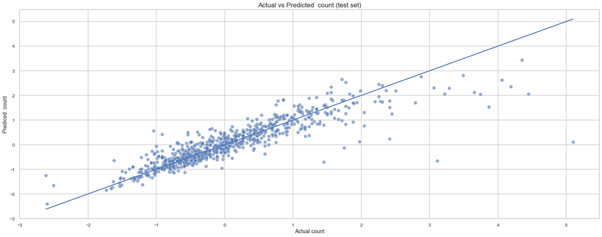

```python
sns.scatterplot(x=y_test, y=y_hat, alpha=0.6)
sns.lineplot(y_test, y_test)

plt.xlabel('Actual count', fontsize=14)
plt.ylabel('Prediced  count', fontsize=14)
plt.title('Actual vs Predicted  count (test set)', fontsize=17)
plt.show()
```

#### The dataframe is heteroskedastic as we get farther out. We could see that i's well fit up to 1, then starts to relatively spread out. The majority of observations are within 1 standard deviation.

e) Report the R squared and the RMSE in the test set. (5 points)

```python
SVM_regression.score(X_test, y_test)
```

```
0.783501371970571
```

```python
MSE_test = round(np.mean(np.square(y_test - y_hat)),2)
RMSE_test = round(np.sqrt(MSE_test),2)
RMSE_test
```

```
0.46
```

1. Tuning the hyperparameters using gridsearchCV. I want you to specifically use the following param grid. my param grid = ’C’: [1,10,100], ’gamma’: [’scaled’,0.1,0.01], ’kernel’: [’rbf ’] (5 points)

```python
my_param_grid = {'C': [1,10,100], 'gamma': [1,0.1,0.01], 'kernel': ['rbf']}
```

1. Re-estimate (Re-fit) the SVM regression model with the optimal parameters from the gridsearch method. Save the predictions as y hat optimized and add this column to the df predictions data frame from part 4.3 in Question 2. (5 points)

```python
from sklearn.model_selection import GridSearchCV
```

```python
GridSearchCV(estimator=SVR(),param_grid= my_param_grid, refit = True, verbose=3, cv=5 )
```

```
GridSearchCV(cv=5, estimator=SVR(),
             param_grid={'C': [1, 10, 100], 'gamma': [1, 0.1, 0.01],
                         'kernel': ['rbf']},
             verbose=3)
```

1. Report the optimized R-squared and RMSE in the test set and compare them with the outputs from part 4.5 in Question 2. (5 points)

```python
grid = GridSearchCV(estimator=SVR(),param_grid= my_param_grid, refit = True, verbose=2, cv=5 )
```

```python
grid.fit(X_train,y_train)
```

```
Fitting 5 folds for each of 9 candidates, totalling 45 fits
[CV] C=1, gamma=1, kernel=rbf ........................................
```

```
[Parallel(n_jobs=1)]: Using backend SequentialBackend with 1 concurrent workers.
```

```
[CV] ......................... C=1, gamma=1, kernel=rbf, total=   0.8s
[CV] C=1, gamma=1, kernel=rbf ........................................
```

```
[Parallel(n_jobs=1)]: Done   1 out of   1 | elapsed:    0.8s remaining:    0.0s
```

[output not shown]

[output cut: 32 more lines]

[output not shown]

```
[Parallel(n_jobs=1)]: Done  45 out of  45 | elapsed:   42.4s finished
```

```
GridSearchCV(cv=5, estimator=SVR(),
             param_grid={'C': [1, 10, 100], 'gamma': [1, 0.1, 0.01],
                         'kernel': ['rbf']},
             verbose=2)
```

1. Estimate the optimized RMSE test using 5 fold cross validation. (5 points)

```python
grid.best_params_
```

```
{'C': 10, 'gamma': 0.01, 'kernel': 'rbf'}
```

```python
grid.best_estimator_
```

```
SVR(C=10, gamma=0.01)
```

```python
y_hat_optimized = grid.predict(X_test)
```

```python
predictions['y_hat_optimized'] = y_hat_optimized
predictions.head()
```

|  | y_test | y_hat | y_hat_optimized |
| --- | --- | --- | --- |
| 30 | -0.221035 | 0.218162 | 0.903822 |
| 837 | -1.005045 | -0.906698 | -0.984276 |
| 3414 | -0.763398 | -1.085833 | -1.147673 |
| 449 | 1.391556 | 0.945573 | 1.013108 |
| 189 | 0.717630 | 0.847015 | 0.830042 |

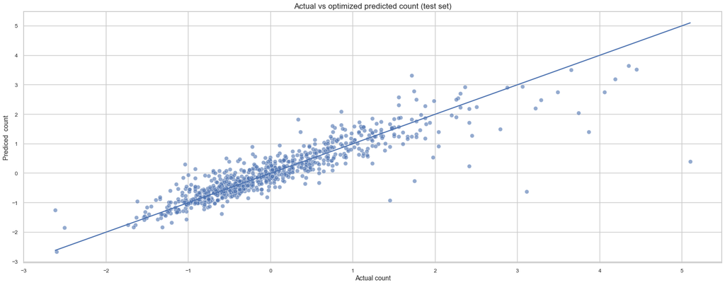

```python
sns.scatterplot(x=y_test, y=y_hat_optimized, alpha=0.6)
sns.lineplot(y_test, y_test)

plt.xlabel('Actual count', fontsize=14)
plt.ylabel('Prediced  count', fontsize=14)
plt.title('Actual vs optimized predicted count (test set)', fontsize=17)
plt.show()
```

```python
grid.score(X_test, y_test)
```

```
0.7938643511248344
```

```python
MSE_test_opt = round(np.mean(np.square(y_test - y_hat_optimized)),2)
RMSE_test_opt = round(np.sqrt(MSE_test_opt),2)
RMSE_test_opt
```

```
0.45
```

### Cross Validation

```python
from sklearn.model_selection import cross_val_score
```

```python
NMSE = cross_val_score(estimator = SVR(C=1, gamma=0.01), X = X_train, y = y_train, cv = 5 , scoring="neg_mean_squared_error" )
```

```python
MSE_CV = round(np.mean(-NMSE),4)
RMSE_CV = round(np.sqrt(MSE_CV),4)
RMSE_CV
```

```
0.4071
```

#### Question 3 SVM Classification (65 points)

Jeff is specifically interested in the DOM variable (Days on the Market) and he wants to make a classifier that predicts if a new listing will be liquid enough or not? i.e. the number of days on the market (for a new listing) is above or below the average DOM. Unfortunately Jeff has not taken the machine learning course yet and he doesn’t know how to apply SVM classification. Could you help him out with the following tasks?

1. Define a binary target variable liquid. liquid = 1 if DOM < average(DOM) and 0 otherwise. What are the proportions of liquid listings vs illiquid ones in the data set? Is the target variable (relatively) balanced or (relatively) imbalanced? (5 points)

```python
# Defining a binary variable DOM:
df_sc["liquid"] = np.where(df_sc["DOM"] < np.mean(df_sc["DOM"]), 1, 0)
df_sc = df_sc.drop("DOM", axis = 1)
```

```python
pd.crosstab(df_sc["liquid"], df_sc["liquid"],  normalize='all')*100
```

| liquid | 0 | 1 |
| --- | --- | --- |
| 0 | 35.860861 | 0.000000 |
| 1 | 0.000000 | 64.139139 |

```python
df_sc.head()
```

|  | Sold Price | Garage Capacity | HOA Fee | Total Bedrooms | Total Bathrooms | Total Square Feet | Irregular Shape_Yes | Quadrant_NW | Quadrant_SE | Quadrant_SW | ... | month_sold_5 | month_sold_6 | month_sold_7 | month_sold_8 | month_sold_9 | month_sold_10 | month_sold_11 | month_sold_12 | built_after_2000_1 | liquid |
| --- | --- | --- | --- | --- | --- | --- | --- | --- | --- | --- | --- | --- | --- | --- | --- | --- | --- | --- | --- | --- | --- |
| 0 | -1.064114 | 0.229046 | -0.572145 | -0.691150 | -1.924239 | -1.382429 | -0.309346 | 2.025697 | -0.578121 | -0.608967 | ... | -0.333519 | -0.359350 | -0.358906 | -0.362008 | 3.232624 | -0.315618 | -0.263262 | -0.241957 | -1.028947 | 1 |
| 1 | -0.537861 | 0.229046 | -0.572145 | 0.176261 | -0.679821 | -0.242012 | -0.309346 | 2.025697 | -0.578121 | -0.608967 | ... | -0.333519 | -0.359350 | 2.786244 | -0.362008 | -0.309346 | -0.315618 | -0.263262 | -0.241957 | -1.028947 | 1 |
| 2 | -0.001941 | 0.229046 | -0.572145 | -0.691150 | -1.924239 | -0.322702 | -0.309346 | 2.025697 | -0.578121 | -0.608967 | ... | -0.333519 | -0.359350 | -0.358906 | -0.362008 | -0.309346 | -0.315618 | 3.798496 | -0.241957 | -1.028947 | 1 |
| 3 | -1.074854 | -0.831521 | -0.572145 | 0.176261 | -1.924239 | -0.425985 | -0.309346 | 2.025697 | -0.578121 | -0.608967 | ... | -0.333519 | 2.782801 | -0.358906 | -0.362008 | -0.309346 | -0.315618 | -0.263262 | -0.241957 | -1.028947 | 1 |
| 4 | -1.031895 | -1.892088 | -0.572145 | 0.176261 | -0.679821 | -1.061821 | -0.309346 | 2.025697 | -0.578121 | -0.608967 | ... | -0.333519 | -0.359350 | -0.358906 | -0.362008 | 3.232624 | -0.315618 | -0.263262 | -0.241957 | -1.028947 | 1 |

5 rows × 46 columns

1. Along with the target variable, define your feature space (X) and split the data into test (20%) and train set (80%) (5 points)

```python
y = df_sc['liquid']
X = df_sc.drop('liquid', axis=1)

from sklearn.model_selection import train_test_split
X_train, X_test, y_train, y_test = train_test_split(X, y, test_size=0.2, random_state = rand_state)
```

1. From sklearn.svm import the relevant function for SVM classification. Do the followings: (30 points)

a) Train the SVM classification model using its default inputs. (5 points)

```python
from sklearn.svm import SVC
```

```python
# Fitting SVM regression to the Training set
SVM_classification = SVC()
SVM_classification.fit(X_train, y_train)
```

```
SVC()
```

b) Make classifications on the test set and save them as y hat (5 points)

```python
# Predicting the Test set results
y_hat = SVM_classification.predict(X_test)
```

c) Construct a data frame named df classifications with 2 columns. y test, and y hat from previous part (5 points)

```python
predictions = pd.DataFrame({ 'y_test':y_test,'y_hat':y_hat})
predictions.tail(10)
```

|  | y_test | y_hat |
| --- | --- | --- |
| 2699 | 1 | 1 |
| 3988 | 0 | 0 |
| 1625 | 1 | 1 |
| 1848 | 0 | 1 |
| 1191 | 1 | 1 |
| 3263 | 1 | 0 |
| 2371 | 1 | 1 |
| 3531 | 1 | 0 |
| 621 | 0 | 1 |
| 1406 | 1 | 1 |

d) Borrow my SVM report() function from the python notebook of the SVM lecture. Report the Accuracy, precision, recall and f1 score along with the confusion matrix. Interpret all of these statistics. Do you trust the accuracy of the model? why? (10 points)

```python
from sklearn.metrics import confusion_matrix
from sklearn.metrics import accuracy_score, recall_score, precision_score, f1_score



def my_SVM_report(X_train, y_train, X_test,y_test, C=1,gamma='scale' ,kernel='rbf'):
    svc= SVC(C=C, gamma=gamma, kernel=kernel)
    svc.fit(X_train, y_train)
    y_hat = svc.predict(X_test)

    cm = confusion_matrix(y_test, y_hat)
    accuracy = round(accuracy_score(y_test,y_hat) ,4)
    error_rate = round(1-accuracy,4)
    precision = round(precision_score(y_test,y_hat),2)
    recall = round(recall_score(y_test,y_hat),2)
    f1score = round(f1_score(y_test,y_hat),2)
    cm_labled = pd.DataFrame(cm, index=['Actual : negative ','Actual : positive'], columns=['Predict : negative','Predict :positive '])

    print("-----------------------------------------")
    print('Accuracy  = {}'.format(accuracy))
    print('Error_rate  = {}'.format(error_rate))
    print('Precision = {}'.format(precision))
    print('Recall    = {}'.format(recall))
    print('f1_score  = {}'.format(f1score))
    print("-----------------------------------------")
    return cm_labled
```

```python
my_SVM_report(X_train, y_train, X_test,y_test, kernel='rbf')
```

```
-----------------------------------------
Accuracy  = 0.6688
Error_rate  = 0.3312
Precision = 0.68
Recall    = 0.89
f1_score  = 0.77
-----------------------------------------
```

|  | Predict : negative | Predict :positive |
| --- | --- | --- |
| Actual : negative | 84 | 209 |
| Actual : positive | 56 | 451 |

e) Can you plot the ROC curve and report the AUC score in SVM classification? why? (5 points)

We cannot plot ROC or AUC in SVM because in SVM classification because this model cannot predict a probability.

1. Tuning the hyperparameters using gridsearchCV. I want you to specifically use the following param grid. my param grid = ’C’: [1,100,1000], ’gamma’: [’scaled’,0.01,0.001], ’kernel’: [’rbf ’] (5 points)

```python
my_param_grid = {'C': [10,100,1000], 'gamma': ['scale',0.01,0.001], 'kernel': ['rbf']}
```

```python
from sklearn.model_selection import GridSearchCV
```

```python
GridSearchCV(estimator=SVC(),param_grid= my_param_grid, refit = True, verbose=2, cv=5 )
```

```
GridSearchCV(cv=5, estimator=SVC(),
             param_grid={'C': [10, 100, 1000], 'gamma': ['scale', 0.01, 0.001],
                         'kernel': ['rbf']},
             verbose=2)
```

```python
grid = GridSearchCV(estimator=SVC(),param_grid= my_param_grid, refit = True, verbose=2, cv=5 )
```

```python
grid.fit(X_train,y_train)
```

```
Fitting 5 folds for each of 9 candidates, totalling 45 fits
[CV] C=10, gamma=scale, kernel=rbf ...................................
```

```
[Parallel(n_jobs=1)]: Using backend SequentialBackend with 1 concurrent workers.
```

```
[CV] .................... C=10, gamma=scale, kernel=rbf, total=   0.5s
[CV] C=10, gamma=scale, kernel=rbf ...................................
```

```
[Parallel(n_jobs=1)]: Done   1 out of   1 | elapsed:    0.5s remaining:    0.0s
```

[output not shown]

[output cut: 32 more lines]

[output not shown]

```
[Parallel(n_jobs=1)]: Done  45 out of  45 | elapsed:   36.5s finished
```

```
GridSearchCV(cv=5, estimator=SVC(),
             param_grid={'C': [10, 100, 1000], 'gamma': ['scale', 0.01, 0.001],
                         'kernel': ['rbf']},
             verbose=2)
```

```python
grid.best_params_
```

```
{'C': 10, 'gamma': 0.01, 'kernel': 'rbf'}
```

```python
grid.best_estimator_
```

```
SVC(C=10, gamma=0.01)
```

1. Re-estimate (Re-fit) the SVM classification model with the optimal parameters from the gridsearch method. Save the predictions as y hat optimized and add this column to the df classifications data frame from part 3.3 in Question 3. (5 points)

```python
y_hat_optimized = grid.predict(X_test)
```

```python
predictions['y_hat_optimized'] = y_hat_optimized
predictions.tail(20)
```

|  | y_test | y_hat | y_hat_optimized |
| --- | --- | --- | --- |
| 198 | 0 | 0 | 0 |
| 1373 | 1 | 1 | 1 |
| 2161 | 1 | 1 | 1 |
| 3332 | 1 | 1 | 1 |
| 3272 | 1 | 0 | 1 |
| 2066 | 0 | 1 | 1 |
| 3449 | 1 | 1 | 1 |
| 1602 | 1 | 1 | 1 |
| 897 | 1 | 1 | 1 |
| 3924 | 1 | 1 | 1 |
| 2699 | 1 | 1 | 1 |
| 3988 | 0 | 0 | 0 |
| 1625 | 1 | 1 | 1 |
| 1848 | 0 | 1 | 1 |
| 1191 | 1 | 1 | 1 |
| 3263 | 1 | 0 | 0 |
| 2371 | 1 | 1 | 1 |
| 3531 | 1 | 0 | 0 |
| 621 | 0 | 1 | 1 |
| 1406 | 1 | 1 | 1 |

1. Report the optimized classification metrics using my SVM report() function and compare them with the outputs from part 3.4 in Question3. (5 points)

```python
my_SVM_report(X_train, y_train, X_test,y_test,C=10, gamma=0.01)
```

```
-----------------------------------------
Accuracy  = 0.66
Error_rate  = 0.34
Precision = 0.69
Recall    = 0.84
f1_score  = 0.76
-----------------------------------------
```

|  | Predict : negative | Predict :positive |
| --- | --- | --- |
| Actual : negative | 100 | 193 |
| Actual : positive | 79 | 428 |

1. Estimate the optimized accuracy test using 5 fold cross validation. (5 points)

```python
from sklearn.model_selection import cross_val_score
```

```python
accuracy = cross_val_score(estimator = SVC(C=10, gamma=0.01), X = X_train, y = y_train, cv = 5 , scoring="accuracy")
```

```python
accuracy
```

```
array([0.6875    , 0.64319249, 0.68231612, 0.67762128, 0.67449139])
```

```python
accuracy_CV=round(accuracy.mean(),4)
accuracy_CV
```

```
0.673
```

1. Why do you think Jeff is interested in predicting the liquidity premium (either positive or negative) of the houses? There may be multiple correct answers to this question. Just list whatever reason seems appropriate to you. (5 points)

One reason could be that Jeff would want to predict whether a house will be liquid and therefore could charge higher prices (a.k.a a liquidity premium). A negative liquidity premium would mean that Jeff should lower the price of the house, especially if the buyer wants to sell it quickly. This can also be beneficial for the buyer, as it will give them an indication of how quickly they need to submit an offer.